# Homework 01

## Question 1 (Least squares and matrix calculations)

Set the random seed to 43201. Generate $n=100$ observations with $p=5$ predictors according to

$$x_{ij}\overset{\mathrm{iid}}{\sim}N(0,1),
\qquad
\varepsilon_i\overset{\mathrm{iid}}{\sim}N(0,0.7^2),$$

with all predictors and errors generated independently. Let

$$\mathbf X
=
\begin{bmatrix}
\mathbf 1 & \mathbf x_1 & \cdots & \mathbf x_5
\end{bmatrix},
\qquad
\boldsymbol\beta
=
(3,1.4,-0.9,0.7,0,1.1)^{\mathsf T},$$

and generate

$$\mathbf y=\mathbf X\boldsymbol\beta+\boldsymbol\varepsilon.$$

```r
set.seed(43201)
n <- 100; p <- 5
X <- matrix(rnorm(n * p), n, p)
eps <- rnorm(n, sd = 0.7)
X_design <- cbind(1, X)
beta <- c(3, 1.4, -0.9, 0.7, 0, 1.1)
y <- X_design %*% beta + eps
```

1. Generate the data and report the dimensions and rank of $\mathbf X$. Calculate the least-squares estimate $\widehat{\boldsymbol\beta}$ using a numerically stable least-squares routine, without explicitly calculating $(\mathbf X^{\mathsf T}\mathbf X)^{-1}$. Compare the estimates with the coefficients used to generate the data.

```r
QR <- qr(X_design)

dim(X_design)
```

```
[1] 100   6
```

```r
QR$rank
```

```
[1] 6
```

```r
beta_hat <- qr.coef(QR, y)

round(cbind(Truth = beta, Estimate = beta_hat), 3)
```

```
     Truth
[1,]   3.0  3.006
[2,]   1.4  1.417
[3,]  -0.9 -0.888
[4,]   0.7  0.795
[5,]   0.0  0.048
[6,]   1.1  1.132
```

2. Calculate the fitted values, the residual vector $\mathbf r=\mathbf y-\mathbf X\widehat{\boldsymbol\beta}$, and the training root mean squared error

$$\operatorname{RMSE}
=
\left(
\frac{1}{n}\sum_{i=1}^{n}r_i^2
\right)^{1/2}.$$

```r
y_hat <- X_design %*% beta_hat

r <- y - y_hat

rmse <- sqrt(mean(r^2))

head(cbind(y, y_hat, r))
```

```
           [,1]      [,2]       [,3]
[1,]  2.5855977  3.653781 -1.0681834
[2,]  4.8481973  5.262543 -0.4143456
[3,] -4.1210840 -3.905647 -0.2154370
[4,]  3.6231206  4.096262 -0.4731415
[5,]  2.2746947  1.287827  0.9868676
[6,]  0.1635792  0.465024 -0.3014448
```

```r
rmse
```

```
[1] 0.6763696
```

3. Report $\lVert\mathbf X^{\mathsf T}\mathbf r\rVert_\infty$. Explain why this value should be close to zero and what it tells us about the residual vector.

```r
Xt_r_norm <- max(abs(t(X_design) %*% r))

Xt_r_norm
```

```
[1] 4.352074e-14
```

## Question 2 (Gaussian likelihood for linear regression)

Continue with the data from Question 1. Suppose

$$\mathbf Y\mid\mathbf X
\sim
N_n\left(\mathbf X\boldsymbol\beta,\sigma^2\mathbf I_n\right).$$

The log-likelihood, including the constant term, is

$$\ell(\boldsymbol\beta,\sigma^2)
=
-\frac{n}{2}\log(2\pi\sigma^2)
-\frac{1}{2\sigma^2}
(\mathbf y-\mathbf X\boldsymbol\beta)^{\mathsf T}
(\mathbf y-\mathbf X\boldsymbol\beta).$$

1. For fixed $\sigma^2$, explain why maximizing $\ell(\boldsymbol\beta,\sigma^2)$ over $\boldsymbol\beta$ is equivalent to minimizing the residual sum of squares. What does this imply about the maximum-likelihood estimate of $\boldsymbol\beta$?

For fixed $\sigma^2$, the first term

$$-\frac{n}{2}\log(2\pi\sigma^2)$$

does not depend on $\boldsymbol{\beta}$, so it is a constant. The only term that depends on $\boldsymbol{\beta}$ is

$$-\frac{1}{2\sigma^2}
(\mathbf{y}-\mathbf{X}\boldsymbol{\beta})^{\mathsf{T}}
(\mathbf{y}-\mathbf{X}\boldsymbol{\beta}).$$

Since $\sigma^2>0$ and this term has a negative sign, maximizing the log-likelihood is equivalent to minimizing the residual sum of squares. Therefore, the maximum-likelihood estimate of $\boldsymbol{\beta}$ is the same as the least-squares estimate from Question 1:

$$\widehat{\boldsymbol{\beta}}_{\mathrm{MLE}}
=
\widehat{\boldsymbol{\beta}}_{\mathrm{LS}}.$$

2. For fixed $\boldsymbol\beta$, differentiate the log-likelihood with respect to $\sigma^2$ and derive its maximum-likelihood estimate. Calculate this estimate at $\widehat{\boldsymbol\beta}$ and compare it with the unbiased estimate of $\sigma^2$. Explain why the two denominators differ.

For fixed $\boldsymbol{\beta}$, let

$$\operatorname{RSS}(\boldsymbol{\beta})
=
(\mathbf{y}-\mathbf{X}\boldsymbol{\beta})^{\mathsf{T}}
(\mathbf{y}-\mathbf{X}\boldsymbol{\beta}).$$

Differentiating the log-likelihood with respect to $\sigma^2$ gives

$$\frac{\partial \ell}{\partial \sigma^2}
=
-\frac{n}{2\sigma^2}
+
\frac{\operatorname{RSS}(\boldsymbol{\beta})}
{2(\sigma^2)^2}.$$

Setting the derivative equal to zero gives

$$\widehat{\sigma}_{\mathrm{MLE}}^2
=
\frac{\operatorname{RSS}(\boldsymbol{\beta})}{n}.$$

```r
rss <- sum(r^2)

n <- length(y)
k <- QR$rank

sigma2_mle <- rss / n
sigma2_unbiased <- rss / (n - k)

round(c(MLE = sigma2_mle,
        Unbiased = sigma2_unbiased), 4)
```

```
     MLE Unbiased
  0.4575   0.4867
```

At $\widehat{\boldsymbol{\beta}}$, the maximum-likelihood estimate is

$$\widehat{\sigma}_{\mathrm{MLE}}^2
=
\frac{\mathbf{r}^{\mathsf{T}}\mathbf{r}}{n}.$$

The MLE uses the denominator $n=100$. The unbiased estimate uses $n-k=100-6=94$, because six regression coefficients, including the intercept, were estimated from the data. Estimating these coefficients uses six degrees of freedom. Therefore, the unbiased estimate is slightly larger than the MLE.

3. Let

$$\mathbf e_{x_2}=(0,0,1,0,0,0)^{\mathsf T}.$$

Using the variance estimate from part b, plot

$$\ell\left(
\widehat{\boldsymbol\beta}+t\mathbf e_{x_2},
\widehat{\sigma}_{\mathrm{MLE}}^2
\right)$$

over a grid of $t$ values from $-1.25$ to $1.25$. State where the maximum occurs and explain why this agrees with the least-squares result.

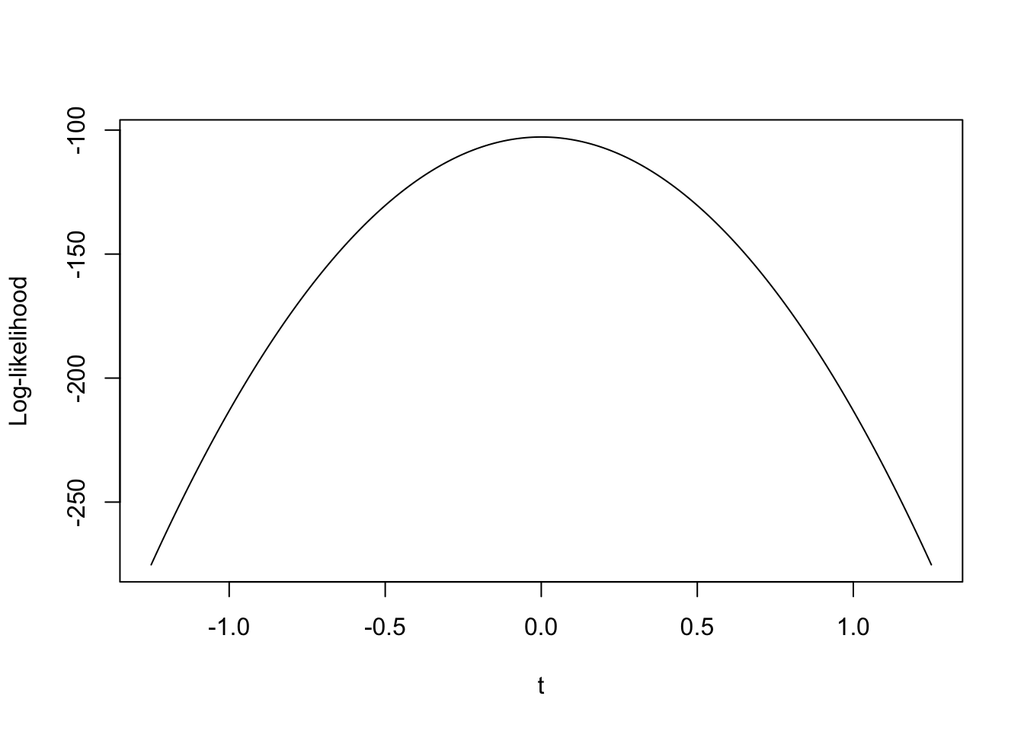

```r
e_x2 <- c(0, 0, 1, 0, 0, 0)

t_values <- seq(-1.25, 1.25, by = 0.01)

loglik_values <- numeric(length(t_values))

for (i in 1:length(t_values)) {
  beta_t <- beta_hat + t_values[i] * e_x2
  residual_t <- y - X_design %*% beta_t

  loglik_values[i] <-
    -n / 2 * log(2 * pi * sigma2_mle) -
    sum(residual_t^2) / (2 * sigma2_mle)
}

plot(
  t_values,
  loglik_values,
  type = "l",
  xlab = "t",
  ylab = "Log-likelihood"
)
```

```r
t_at_max <- t_values[which.max(loglik_values)]
round(t_at_max, 2)
```

```
[1] 0
```

## Question 3 (Starting values in nonconvex optimization)

Consider the function

$$f(x)=\exp(1.5x)-3(x+6)^2-0.05x^3,$$

with derivative

$$f'(x)=1.5\exp(1.5x)-6(x+6)-0.15x^2.$$

1. Plot $f(x)$ over the interval $[-40,7]$. Based on the plot, describe the important features of the objective function that may affect numerical optimization.

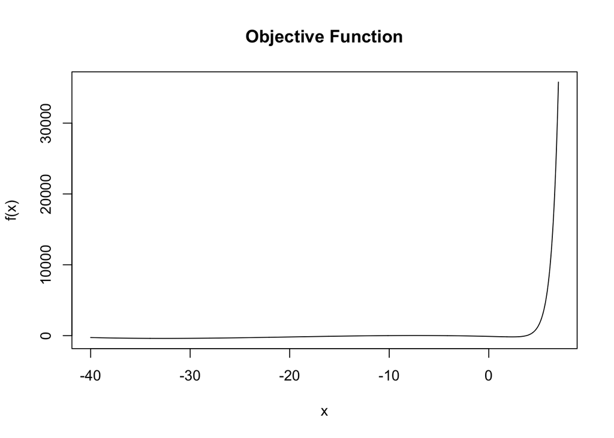

```r
f <- function(x) {
  exp(1.5 * x) - 3 * (x + 6)^2 - 0.05 * x^3
}

curve(
  f(x),
  from = -40,
  to = 7,
  n = 1000,
  xlab = "x",
  ylab = "f(x)",
  main = "Objective Function"
)
```

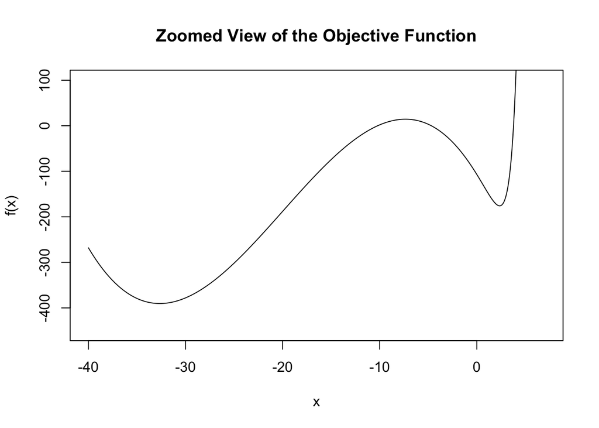

```r
curve(
  f(x),
  from = -40,
  to = 7,
  n = 1000,
  ylim = c(-450, 100),
  xlab = "x",
  ylab = "f(x)",
  main = "Zoomed View of the Objective Function"
)
```

The function is nonconvex. It has two local minima, near $x=-32.65$ and $x=2.35$, and a local maximum near $x=-7.35$. The local minimum near $x=-32.65$ has the lower objective value. The exponential term also makes the function increase very quickly for positive values of $x$. Therefore, different starting values may cause the optimizer to converge to different local minima.

2. Use BFGS to minimize $f(x)$ twice, starting at $x^{(0)}=-15$ and $x^{(0)}=0$. Supply $f'(x)$ to the optimizer. For each run, report the final value of $x$, the final objective value, $|f'(x)|$, and whether the optimizer reported convergence.

```r
f <- function(x) {
  exp(1.5 * x) - 3 * (x + 6)^2 - 0.05 * x^3
}

f_prime <- function(x) {
  1.5 * exp(1.5 * x) - 6 * (x + 6) - 0.15 * x^2
}

fit_1 <- optim(
  par = -15,
  fn = f,
  gr = f_prime,
  method = "BFGS"
)

fit_2 <- optim(
  par = 0,
  fn = f,
  gr = f_prime,
  method = "BFGS"
)

results <- data.frame(
  Start = c(-15, 0),
  Final_x = round(c(fit_1$par, fit_2$par), 6),
  Final_f = round(c(fit_1$value, fit_2$value), 6),
  Abs_derivative = signif(
    c(abs(f_prime(fit_1$par)),
      abs(f_prime(fit_2$par))),
    4
  ),
  Converged = c(
    fit_1$convergence == 0,
    fit_2$convergence == 0
  )
)

results
```

```
  Start    Final_x   Final_f Abs_derivative Converged
1   -15 -32.649111 -390.3858      8.725e-08      TRUE
2     0   2.349967 -175.8626      6.556e-07      TRUE
```

Starting at $x^{(0)}=-15$, BFGS converged to approximately $x=-32.6491$, with an objective value of $-390.3858$. Starting at $x^{(0)}=0$, BFGS converged to approximately $x=2.3500$, with an objective value of $-175.8626$. In both runs, $|f'(x)|$ is close to zero and the optimizer reported convergence.

3. Explain why the two runs can converge to different answers. Which run gives the lower objective value? What additional evidence would be needed before claiming that this point is the global minimum?

The two runs can converge to different answers because the function is nonconvex and has more than one local minimum. BFGS is a local optimization method, so its result can depend on the starting value.

The run starting at $x^{(0)}=-15$ gives the lower objective value:

$$f(-32.6491)\approx -390.3858,$$

compared with

$$f(2.3500)\approx -175.8626$$

for the run starting at $x^{(0)}=0$.

However, convergence and a value of $|f'(x)|$ close to zero only show that the point is a local minimum. Before claiming that it is the global minimum, we would need to check all stationary points and compare their objective values. We should also examine the function outside the plotted interval or show that $f(x)\to\infty$ as $x\to\pm\infty$.

## Question 4 (Nearly collinear predictors)

Continue with $\mathbf X$ and $\mathbf y$ from Question 1. Set the random seed to 43202 and generate

$$u_i\overset{\mathrm{iid}}{\sim}N(0,1),
\qquad i=1,\ldots,n.$$

Define

$$\mathbf x_6=\mathbf x_1+10^{-4}\mathbf u,
\qquad
\mathbf X_+
=
\begin{bmatrix}
\mathbf X & \mathbf x_6
\end{bmatrix},$$

and let

$$\mathbf y^\star=\mathbf y+10^{-3}\mathbf u.$$

Use a numerically stable least-squares routine throughout.

1. Fit $\mathbf y$ using $\mathbf X$ and $\mathbf X_+$. For each design matrix, report the condition number and training RMSE. For the augmented fit, also report the coefficients of $\mathbf x_1$ and $\mathbf x_6$.

```r
set.seed(43202)
u <- rnorm(n)

x1 <- X_design[, 2]
x6 <- x1 + 10^(-4) * u

X_plus <- cbind(X_design, x6)
y_star <- y + 10^(-3) * u

QR_X <- qr(X_design)
beta_X <- qr.coef(QR_X, y)
fitted_X <- X_design %*% beta_X
rmse_X <- sqrt(mean((y - fitted_X)^2))

QR_plus <- qr(X_plus)
beta_plus <- qr.coef(QR_plus, y)
fitted_plus <- X_plus %*% beta_plus
rmse_plus <- sqrt(mean((y - fitted_plus)^2))

results_a <- data.frame(
  Design = c("X", "X_plus"),
  Condition_number = signif(
    c(
      kappa(X_design, exact = TRUE),
      kappa(X_plus, exact = TRUE)
    ),
    6
  ),
  Training_RMSE = round(
    c(rmse_X, rmse_plus),
    6
  )
)

results_a
```

```
  Design Condition_number Training_RMSE
1      X          1.52491      0.676370
2 X_plus      20209.20000      0.675467
```

```r
round(
  c(
    x1 = beta_plus[2],
    x6 = beta_plus[7]
  ),
  6
)
```

```
       x1        x6
 351.6766 -350.2588
```

The augmented design matrix has a much larger condition number because $x_6$ is almost identical to $x_1$. However, the two training RMSE values are nearly the same, so adding $x_6$ changes the fitted values very little. The separate coefficients of $x_1$ and $x_6$ can be unstable because the two predictors are nearly collinear.

2. Fit $\mathbf y^\star$ using $\mathbf X_+$. Report the changes in the coefficients of $\mathbf x_1$ and $\mathbf x_6$. Compare the two fitted-value vectors using their root mean squared difference and maximum absolute difference.

```r
beta_plus_star <- qr.coef(QR_plus, y_star)

fitted_plus_star <- X_plus %*% beta_plus_star

coefficient_comparison <- cbind(
  Fit_y = beta_plus[c(2, 7)],
  Fit_y_star = beta_plus_star[c(2, 7)],
  Change = beta_plus_star[c(2, 7)] - beta_plus[c(2, 7)]
)

rownames(coefficient_comparison) <- c("x1", "x6")

round(coefficient_comparison, 6)
```

```
       Fit_y Fit_y_star Change
x1  351.6766   341.6766    -10
x6 -350.2588  -340.2588     10
```

```r
fitted_difference <- fitted_plus_star - fitted_plus

rms_difference <- sqrt(mean(fitted_difference^2))

max_absolute_difference <- max(abs(fitted_difference))

round(
  c(
    RMS_difference = rms_difference,
    Maximum_absolute_difference = max_absolute_difference
  ),
  6
)
```

```
             RMS_difference Maximum_absolute_difference
                   0.001016                    0.002573
```

After changing the response from $\mathbf{y}$ to $\mathbf{y}^*$, the coefficient of $x_1$ decreases by approximately 10, while the coefficient of $x_6$ increases by approximately 10. However, the root mean squared difference and maximum absolute difference between the two fitted-value vectors are very small. Therefore, a small change in the response causes large changes in the individual coefficients but only a small change in the fitted values.

3. Use the identity

$$\mathbf y^\star-\mathbf y
=
10(\mathbf x_6-\mathbf x_1)$$

to explain why the fitted values change very little while the two coefficients change substantially. What does this example suggest about interpreting separate effects for nearly collinear predictors?

Since

$$\mathbf{x}_6-\mathbf{x}_1=10^{-4}\mathbf{u},$$

we have

$$10(\mathbf{x}_6-\mathbf{x}_1)
=
10^{-3}\mathbf{u}
=
\mathbf{y}^{*}-\mathbf{y}.$$

Therefore, changing the coefficient of $x_1$ by $-10$ and the coefficient of $x_6$ by $+10$ changes the fitted values by

$$-10\mathbf{x}_1+10\mathbf{x}_6
=
10(\mathbf{x}_6-\mathbf{x}_1)
=
\mathbf{y}^{*}-\mathbf{y}.$$

The coefficients change substantially, but the fitted values change only by the small amount $10^{-3}\mathbf{u}$. This happens because $x_1$ and $x_6$ are nearly identical. Their separate effects cannot be estimated reliably. For nearly collinear predictors, the combined effect may be stable, but the individual coefficients can be unstable and should be interpreted with caution.

## Question 5 (Data preparation and summary statistics)

The file `data/data-manipulation.csv` is a small constructed data table containing an observation identifier, a group label, two numeric predictors, and a response. Some response values are missing. For analyses involving the response, use only observations with a recorded response. Do not replace a missing response with zero or a group mean.

1. Read the data and report its dimensions, column types, number of duplicated identifiers, and number of missing values in each column. Create an analysis table containing only observations with a recorded response, and define

$$\texttt{feature\_sum}=\texttt{x1}+\texttt{x2}.$$

```r
raw_data <- read.csv("data/data-manipulation.csv")

dim(raw_data)
```

```
[1] 24  5
```

```r
sapply(raw_data, class)
```

```
observation_id          group             x1             x2       response
   "character"    "character"      "numeric"      "numeric"      "numeric"
```

```r
sum(duplicated(raw_data$observation_id))
```

```
[1] 0
```

```r
colSums(is.na(raw_data))
```

```
observation_id          group             x1             x2       response
             0              0              0              0              3
```

```r
analysis_data <- raw_data[!is.na(raw_data$response), ]

analysis_data$feature_sum <- analysis_data$x1 + analysis_data$x2

dim(analysis_data)
```

```
[1] 21  6
```

```r
head(analysis_data)
```

```
  observation_id group  x1  x2 response feature_sum
1         obs-01     A 1.2 2.0     5.36         3.2
2         obs-02     A 2.4 1.1     6.18         3.5
3         obs-03     A 0.8 2.8     4.62         3.6
5         obs-05     A 2.0 2.2     5.52         4.2
6         obs-06     A 1.7 1.8     5.64         3.5
7         obs-07     A 2.8 0.9     7.18         3.7
```

The data were read from the CSV file. I reported the dimensions, column types, number of duplicated observation identifiers, and number of missing values in each column. For the analysis table, I kept only observations with a recorded response and created `feature_sum` as the sum of `x1` and `x2`. Missing responses were not replaced with zero or a group mean.

2. For each group, report the number of observations, the mean response, and the mean of `feature_sum`. State clearly which observations these summaries describe.

```r
group_n <- aggregate(
  response ~ group,
  data = analysis_data,
  FUN = length
)
names(group_n)[2] <- "n"

group_response <- aggregate(
  response ~ group,
  data = analysis_data,
  FUN = mean
)
names(group_response)[2] <- "mean_response"

group_feature <- aggregate(
  feature_sum ~ group,
  data = analysis_data,
  FUN = mean
)
names(group_feature)[2] <- "mean_feature_sum"

group_summary <- merge(group_n, group_response, by = "group")
group_summary <- merge(group_summary, group_feature, by = "group")

group_summary
```

```
  group n mean_response mean_feature_sum
1     A 7      5.600000         3.600000
2     B 7      7.602857         4.928571
3     C 7      7.997143         6.585714
```

These summaries describe only the observations in `analysis_data`. Therefore, they include only observations with a recorded, nonmissing response. Observations with a missing response in the original data are not included.

3. Sort the analysis table by response from largest to smallest and report the first three rows, including `observation_id`, `group`, `response`, and `feature_sum`. Add code checks verifying that the number of retained rows equals the number of nonmissing responses in the original data, that the analysis table has no missing response values, and that its identifiers are unique.

```r
analysis_sorted <- analysis_data[
  order(analysis_data$response, decreasing = TRUE),
]

head(
  analysis_sorted[
    , c("observation_id", "group", "response", "feature_sum")
  ],
  3
)
```

```
   observation_id group response feature_sum
22         obs-22     C     9.24         6.6
16         obs-16     B     9.00         5.2
14         obs-14     B     8.66         5.0
```

```r
checks <- c(
  retained_rows_match =
    nrow(analysis_data) == sum(!is.na(raw_data$response)),

  no_missing_responses =
    all(!is.na(analysis_data$response)),

  unique_identifiers =
    !any(duplicated(analysis_data$observation_id))
)

checks
```

```
 retained_rows_match no_missing_responses   unique_identifiers
                TRUE                 TRUE                 TRUE
```

All three checks return `TRUE`. Therefore, the analysis table contains all and only observations with recorded responses, has no missing response values, and has unique observation identifiers.

## Question 6 (Can 39 million Fitbit records represent US adults?)

[Patten et al. (2026)](https://doi.org/10.1038/s41591-026-04352-3) describe Fitbit data from 59,018 participants in the All of Us Research Program. The dataset spans 14 years and contains more than 39 million daily step records. Participants contributed data through one of two routes:

- Bring Your Own Device (BYOD): participants shared data from a Fitbit they already owned.
- Wearables Enhancing All of Us Research (WEAR): invited participants received a Fitbit at no cost.

In the general activity cohort, the BYOD and WEAR groups contained 32,035 and 22,474 participants, respectively. The BYOD value is listed first in each comparison below:

- 77.3% versus 55.1% reported being White;
- 6.1% versus 15.2% reported annual household income between $\$10{,}000$ and $\$25{,}000$; and
- median daily steps were 6,867 versus 5,797.

Suppose the target is the mean of the participant-specific average daily step counts among US adults during the study period, with each adult given equal weight. A researcher writes:

> “This dataset contains more than 39 million daily Fitbit records. Therefore, the average of all recorded step counts should provide an accurate estimate of mean daily activity among US adults.”
1. Are the 39 million daily records independent observations? What characteristics or behaviors could cause some participants to contribute more recorded days than others? Explain how averaging all recorded days would then weight participants unequally.

No, the 39 million daily records are not independent observations. Many daily records come from the same participant, so records from the same person are likely to be related.

Participants may contribute different numbers of recorded days because they joined the study at different times, wore or synchronized their Fitbit with different frequency, stopped using the device, had battery or technical problems, or differed in motivation and health behavior.

If all daily records are averaged together, participants with more recorded days receive more weight. For example, a participant with 1,000 recorded days has ten times the influence of a participant with 100 recorded days. Therefore, this average does not give every participant equal weight and may be biased if the number of recorded days is related to activity level or participant characteristics.

2. BYOD participants reported a median of 6,867 daily steps, compared with 5,797 among WEAR participants. Does this comparison show that already owning a Fitbit causes people to walk more? Explain your answer and give at least one plausible alternative explanation based on how participants entered the two groups.

No, this comparison does not show that owning a Fitbit causes people to walk more. The participants were not randomly assigned to the BYOD and WEAR groups. People in the BYOD group already chose to buy and use a Fitbit, so they may have been more active or more interested in health before entering the study.

Another possible explanation is that the two groups had different backgrounds. For example, the BYOD group had a smaller percentage of low-income participants. Income, health, age, and lifestyle may affect both Fitbit ownership and daily steps. Therefore, the comparison shows an association, but it does not prove causation.

3. A very large dataset can still produce a biased estimate of a population quantity when the people and observations entering the dataset are selected. Using this study, explain how selection of both participants and recorded days could make the observed data differ from the US adult population. Why might the naive average of all recorded daily step counts fail to estimate the stated target? You do not need to determine the direction of the bias.

A large dataset can still be biased if the participants are not representative of the target population. The study participants either already owned a Fitbit or agreed to wear one provided by the study. They may differ from other US adults in income, race, health, interest in exercise, and use of technology.

The recorded days may also be selected. Participants may not wear or sync their Fitbit every day, and missing days may be related to their activity, health, travel, or motivation. In addition, some participants contributed many more recorded days than others.

A naive average of all daily records gives more weight to participants with more recorded days. However, the target gives every US adult equal weight and is based on each person’s average daily steps. Therefore, having 39 million records does not remove selection bias, and the naive average may not accurately estimate the stated target.

### Source

Patten, T., Preble, E. A., Master, H., et al. (2026). [The All of Us Research Program’s wearables dataset](https://doi.org/10.1038/s41591-026-04352-3). *Nature Medicine*, 32, 2302-2310.